# QBio305 - Genetic analysis of phenotypic variation measured in the Oregon Wolfe Barley collection

- Show All Code
- Hide All Code
- View Source

Author

Ingo Giebel

Published

December 26, 2023

MIT License

Copyright (c) 2023 Ingo Giebel

Permission is hereby granted, free of charge, to any person obtaining a copy of this software and associated documentation files (the “Software”), to deal in the Software without restriction, including without limitation the rights to use, copy, modify, merge, publish, distribute, sublicense, and/or sell copies of the Software, and to permit persons to whom the Software is furnished to do so, subject to the following conditions:

The above copyright notice and this permission notice shall be included in all copies or substantial portions of the Software.

THE SOFTWARE IS PROVIDED “AS IS”, WITHOUT WARRANTY OF ANY KIND, EXPRESS OR IMPLIED, INCLUDING BUT NOT LIMITED TO THE WARRANTIES OF MERCHANTABILITY, FITNESS FOR A PARTICULAR PURPOSE AND NONINFRINGEMENT. IN NO EVENT SHALL THE AUTHORS OR COPYRIGHT HOLDERS BE LIABLE FOR ANY CLAIM, DAMAGES OR OTHER LIABILITY, WHETHER IN AN ACTION OF CONTRACT, TORT OR OTHERWISE, ARISING FROM, OUT OF OR IN CONNECTION WITH THE SOFTWARE OR THE USE OR OTHER DEALINGS IN THE SOFTWARE.

# R Packages and options

## Load the required packages

```r
# For determining the project root
library(here)
# For transforming and representing data
library(tidyverse)
# For plotting
library(ggpubr)
# For Levene's test
library(car)
# For linkage analysis
library(qtl)
```

## Set R option for scientific notation

```r
options(scipen = 1)
options(pillar.sigfig = 4)
```

# Data import

## Define the file paths

```r
dta_owb_genetic_map_file_path <- here::here(
  "data",
  "dta_owb_genetic_map.csv"
)

dta_owb_height_and_spike_length_by_genotype_file_path <- here::here(
  "data",
  "dta_owb_height_and_spike_length_by_genotype.csv"
)

dta_owb_linkage_map_qualt_phenotypes_file_path <- here::here(
  "data",
  "dta_owb_linkage_map_qualt_phenotypes.csv"
)
```

## Read in the data

```r
# Read in the raw quantitative data of the different OWB genotypes
dta_quant_raw <- car::strings2factors(
  readr::read_csv(dta_owb_height_and_spike_length_by_genotype_file_path),
  verbose = FALSE
)

# Read in the genetic map of OWB
dta_owb_genetic_map <- readr::read_csv(
  dta_owb_genetic_map_file_path
)

# Read in linkage map and qualitative phenotypes as denoted in
# marker annotation
dta_linkage_map_qualt_phenotypes <- qtl::read.cross(
  format = "csv",
  file = dta_owb_linkage_map_qualt_phenotypes_file_path,
  genotypes = c("a", "b"),
  alleles = c("a", "b"),
  crosstype = "dh"
)
```

# Analyses for plant height

## Function definitions

```r
# Plot a histogram of the residuals
plot_residuals_hist <- function(data_aov, xlab) {
  res <- data_aov$residuals
  ggplot2::ggplot(
    data = data.frame(
      1:length(res),
      res
    ),
    mapping = ggplot2::aes(x = res),
  ) +
    ggplot2::geom_histogram(
      mapping = ggplot2::aes(y = ggplot2::after_stat(width * density)),
      color = "darkgrey",
      bins = 50
    ) +
    ggplot2::stat_function(
      fun = dnorm,
      args = list(
        mean = mean(res),
        sd = sd(res)
      ),
      color = "darkred"
    ) +
    ggplot2::labs(
      x = xlab,
      y = "Density"
    )
}

# Conduct an ANOVA of phenotype ~ marker for each marker within marker_names
anova_all_markers <- function(data, genetic_map, phenotype, marker_names) {
  # Tibble for the markers, theirs positions and significance values for the
  # phenotype
  marker_pval_df <- tibble::tibble(
    marker = character(),
    chr = character(),
    pos = numeric(),
    pval = numeric()
  )

  # Loop through all markers and conduct ANOVAs for each one of them
  for (marker_name in marker_names) {
    # Extract the marker's genetic position from the genetic map
    marker_chr_pos <- dplyr::filter(genetic_map, marker == marker_name)
    # Conduct an one-way ANOVA of the phenotype vs the marker
    marker_aov <- aov(
      as.formula(paste(phenotype, "~", marker_name)),
      data = data
    )
    # Extract the marker's p-value from the ANOVA table
    pval <- summary(marker_aov)[[1]][1, 5]
    # Add a new row for the marker, its position, and its p-value
    marker_pval_df <-
      marker_pval_df |>
      tibble::add_row(marker_chr_pos, pval)
  }

  marker_pval_df
}
```

## ANOVA height ~ genotype

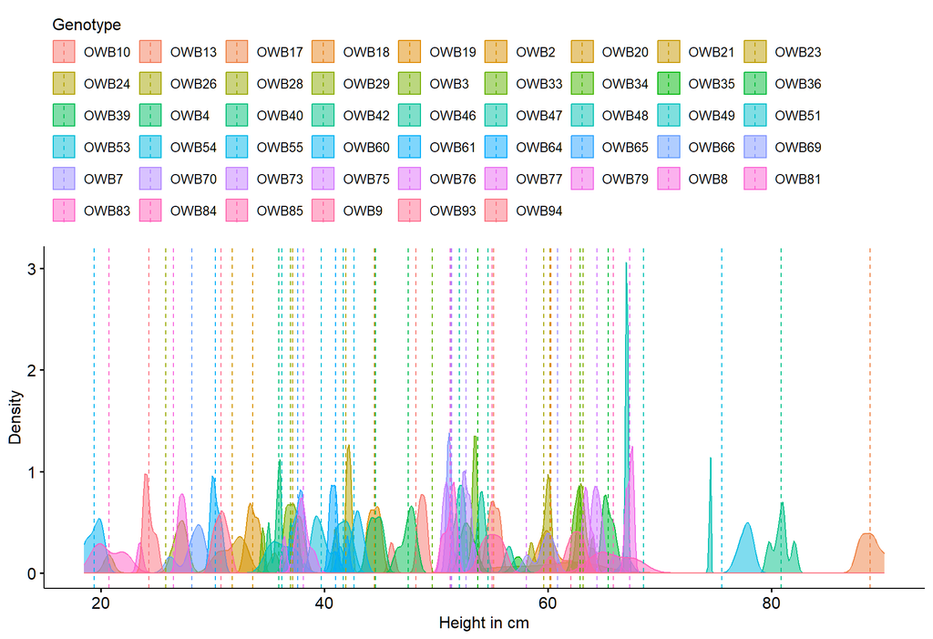

```r
# Densitiy plot comparing the height of the different genotypes
ggpubr::ggdensity(
  data = dta_quant_raw,
  x = "Height",
  add = "mean",
  color = "Genotype",
  fill = "Genotype",
  xlab = "Height in cm",
  ylab = "Density",
) +
  ggplot2::theme(legend.justification = c("left", "top")) +
  ggplot2::guides(
    colour = ggplot2::guide_legend(
      title.position = "top",
      nrow = 6,
      byrow = TRUE
    )
  )
```

```r
# Summary statistics per genotype
dta_quant_raw |>
  dplyr::select(Genotype, Height) |>
  dplyr::group_by(Genotype) |>
  dplyr::summarise(
    Count = n(),
    Mean = mean(Height),
    Sd = sd(Height)
  )
```

```
# A tibble: 51 × 4
   Genotype Count  Mean     Sd
   <fct>    <int> <dbl>  <dbl>
 1 OWB10        5 48.2  1.255
 2 OWB13        5 55.14 0.4722
 3 OWB17        5 88.82 0.8729
 4 OWB18        5 60.24 1.043
 5 OWB19        5 44.46 0.4561
 6 OWB2         5 33.6  0.4899
 7 OWB20        5 31.76 1.045
 8 OWB21        5 60.18 3.503
 9 OWB23        5 37.16 1.001
10 OWB24        5 41.92 0.5357
# ℹ 41 more rows
```

```r
# Fit an analysis of variance model for the height vs genotype
height_raw_aov <- aov(Height ~ Genotype, data = dta_quant_raw)

# Summary of the ANOVA analysis
summary(height_raw_aov)
```

```
             Df Sum Sq Mean Sq F value Pr(>F)
Genotype     50  61466  1229.3   198.1 <2e-16 ***
Residuals   203   1260     6.2
---
Signif. codes:  0 '***' 0.001 '**' 0.01 '*' 0.05 '.' 0.1 ' ' 1
```

**Conclusion:** The genotype has a significant effect on the plant height (p-value < $2 \times 10^{-16}$).

## Check the homogeneity of the raw data

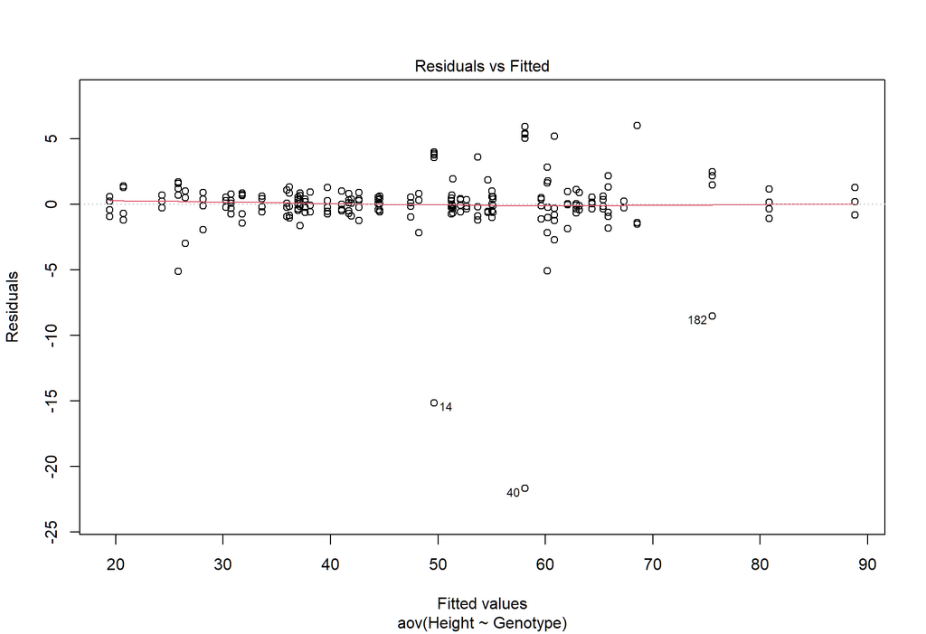

```r
# ANOVA assumes that the data are normally distributed and that the
# variance across the groups is approximately equal. These assumptions
# are assessed with some diagnostic plots and tests.

# Plot the residuals vs fit in order to check the homogeneity of variance
# assumption
plot(height_raw_aov, which = 1)
```

```r
# Levene's test for homogeneity of variance across groups
car::leveneTest(Height ~ Genotype, data = dta_quant_raw)
```

```
Levene's Test for Homogeneity of Variance (center = median)
       Df F value Pr(>F)
group  50  0.8208 0.7938
      203
```

**Conclusion:** The variances are roughly homogeneous. The p-value for the Levene’s test of the raw data is 0.7938. This means that the variances within the groups are not significantly different from each other, i.e., the homogeneity assumption of the variance is met.

**Outliers:** The rows 14, 40, and 182 are detected as outliers, which can severely affect normality and homogeneity of the variance. Therefore, these outliers (in the genotypes OWB33, OWB76, and OWB54) will be removed to meet the test assumptions.

## Check the normality of the raw data

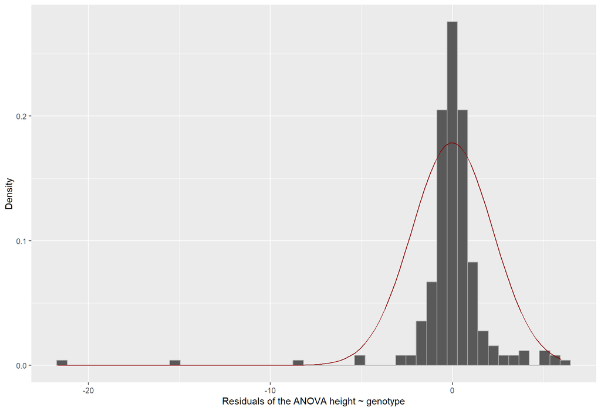

```r
# Plot a histogram of the residuals
plot_residuals_hist(
  height_raw_aov,
  "Residuals of the ANOVA height ~ genotype")
```

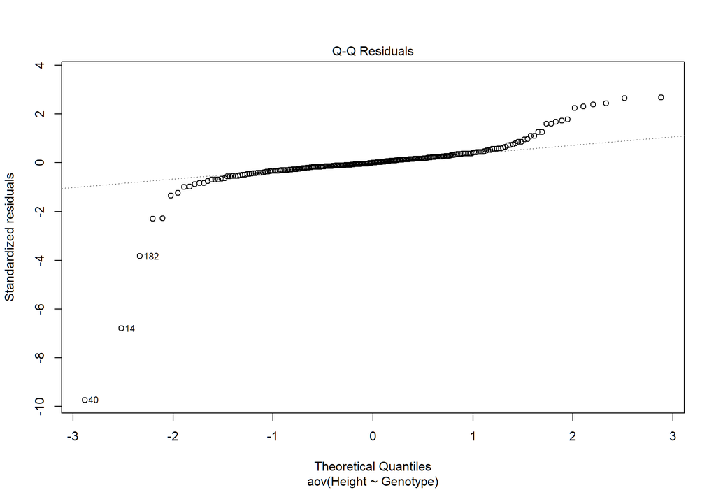

```r
# Q-Q plot of the ANOVA residuals
plot(height_raw_aov, which = 2)
```

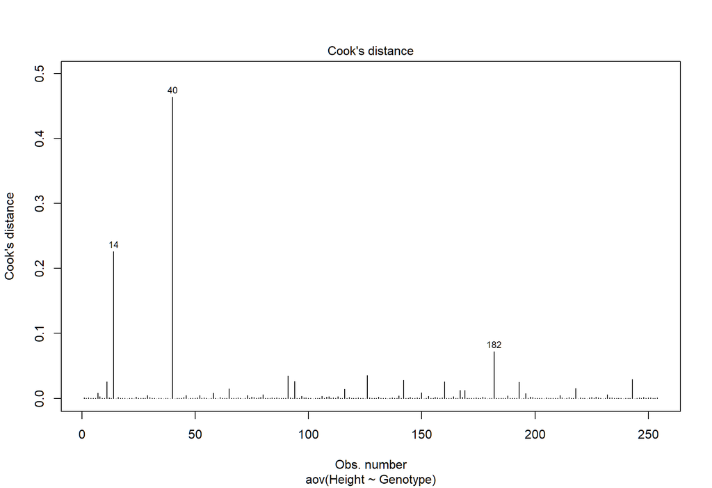

```r
# Cook's distance plot
plot(height_raw_aov, which = 4)
```

```r
# Shapiro-Wilk test for normality
shapiro.test(height_raw_aov$residuals)
```

```
    Shapiro-Wilk normality test

data:  height_raw_aov$residuals
W = 0.58279, p-value < 2.2e-16
```

**Conclusion:** According to the Shapiro-Wilk test for normality, it is unlikely that the raw data is normally distributed (p-values < $2.2 \times 10^{-16}$). Nevertheless, the plots reveal that the data conform at least roughly to a normal distribution, in particular without the three outliers. Therefore, the further analysis will be done using ANOVA with cleansed data (without the outliers).

## Cleanse the data

```r
# Remove outliers
dta_quant_clean <- dta_quant_raw[-c(14, 40, 182), ]

# Fit an analysis of variance model for the height (cleansed data)
height_clean_aov <- aov(Height ~ Genotype, data = dta_quant_clean)

# Summary of the ANOVA analysis
summary(height_clean_aov)
```

```
             Df Sum Sq Mean Sq F value Pr(>F)
Genotype     50  61746  1234.9   838.4 <2e-16 ***
Residuals   200    295     1.5
---
Signif. codes:  0 '***' 0.001 '**' 0.01 '*' 0.05 '.' 0.1 ' ' 1
```

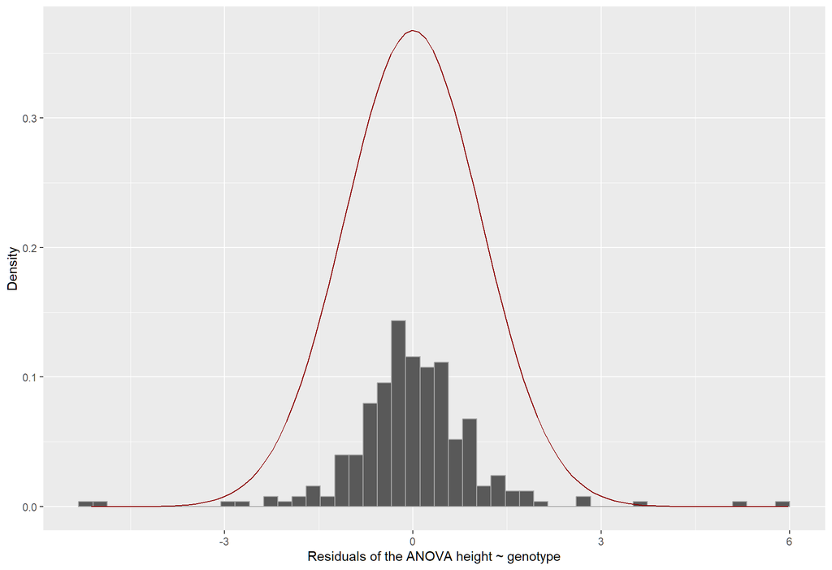

Figure 1: Histogram of the ANOVA residuals - clean data

```r
# Plot a histogram of the residuals
plot_residuals_hist(
  height_clean_aov,
  "Residuals of the ANOVA height ~ genotype"
)
```

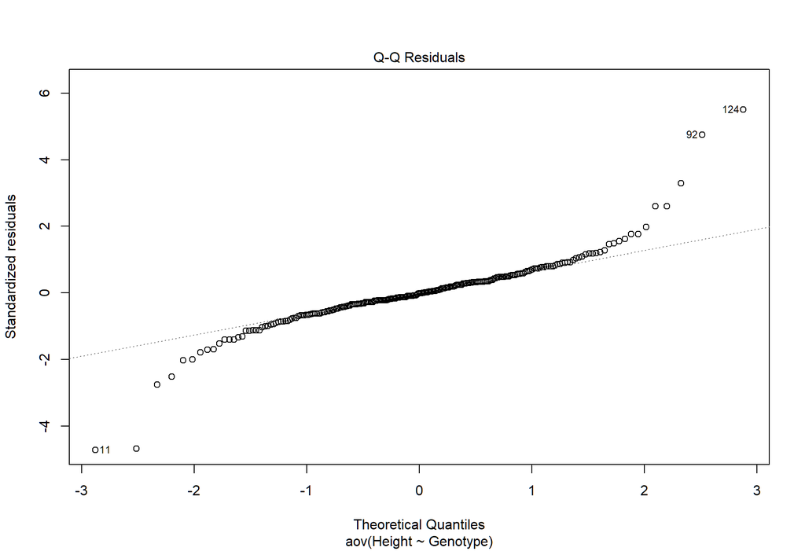

Figure 2: Q-Q plot of the ANOVA residuals - clean data

```r
# Q-Q plot of the ANOVA residuals
plot(height_clean_aov, which = 2)
```

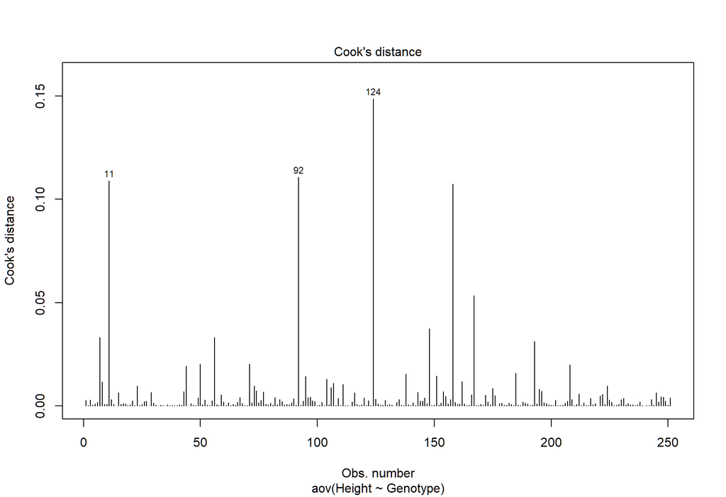

Figure 3: Cook’s distance plot of the ANOVA residuals - clean data

```r
# Cook's distance plot
plot(height_clean_aov, which = 4)
```

```r
# Shapiro-Wilk test for normality
shapiro.test(height_clean_aov$residuals)
```

```
    Shapiro-Wilk normality test

data:  height_clean_aov$residuals
W = 0.86892, p-value = 7.823e-14
```

**Conclusion:** According to the Shapiro-Wilk test for normality, it is still unlikely that the cleansed data is normally distributed (p-value = $7.823 \times 10^{-14}$. Nevertheless, the plots reveal that the data conform at least roughly to a normal distribution, in particular without the removed three outliers.

## QTL analysis of plant height

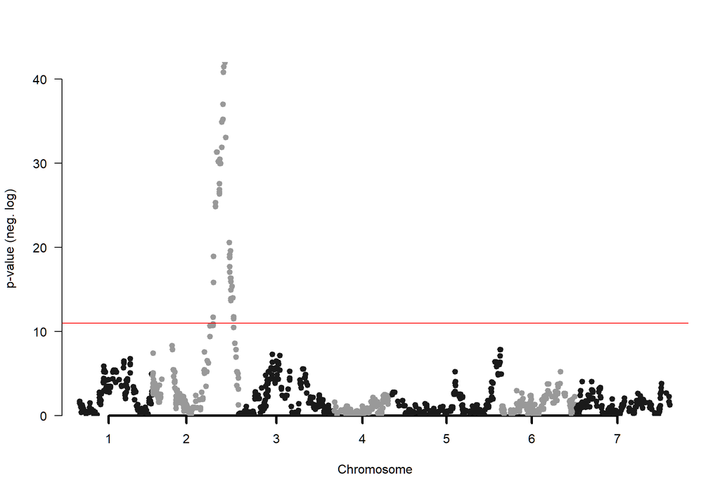

Figure 4: Manhattan plot of the genome-wide p-values for the genetic markers

```r
marker_pval_df <- anova_all_markers(
  dta_quant_clean,
  dta_owb_genetic_map,
  "Height",
  colnames(dta_quant_clean)[5:ncol(dta_quant_clean)]
)

# Calculate the Bonferroni corrected significance threshold. The Bonferroni
# correction adjusts the chosen significance level (here 5 %) by dividing it
# by the number of tests.
sig_thld_bonfcorr <- 0.05 / nrow(marker_pval_df)

# Create a data frame that follows the requirements of the
# Manhattan command of the qqman library
marker_pval_manhattan_plot_df <- marker_pval_df |>
  dplyr::mutate(CHR = as.numeric(gsub("H", "", chr))) |>
  dplyr::rename(BP = pos) |>
  dplyr::mutate(SNP = 1:n(), .before = pval) |>
  dplyr::select(CHR, BP, SNP, pval)

# Manhattan plot of the genome-wide p-values for the markers
qqman::manhattan(
  marker_pval_manhattan_plot_df,
  genomewideline = -log(sig_thld_bonfcorr),
  suggestiveline = FALSE,
  logp = TRUE,
  p = "pval",
  lwd = 3,
  ylab = "p-value (neg. log)"
)
```

```r
# Determine all gene positions which have p-value less than the
# Bonferroni corrected p-value
marker_pval_sig_df <- marker_pval_df |>
  dplyr::filter(pval < sig_thld_bonfcorr) |>
  dplyr::rename(Chr = chr) |>
  dplyr::group_by(Chr) |>
  dplyr::summarise(
    Count = n(),
    "Min p-val" = min(pval),
    "Median p-val" = median(pval),
    "Min pos" = min(pos),
    "Max pos" = max(pos)
  )
marker_pval_sig_df
```

```
# A tibble: 5 × 6
  Chr   Count `Min p-val` `Median p-val` `Min pos` `Max pos`
  <chr> <int>       <dbl>          <dbl>     <dbl>     <dbl>
1 1H       37   1.740e- 7      4.238e- 6     52.67     157.1
2 2H      180   1.105e-42      1.817e-14      1.26     186.6
3 3H       68   5.427e- 8      2.568e- 6     58.63     146.3
4 5H       38   1.476e- 8      4.450e- 7    136.6      237.8
5 6H        1   6.366e- 6      6.366e- 6    128.8      128.8
```

**Conclusion:** The plant height is mainly significantly effected by a genomic region within gene 2H. But there are also markers within the genes 1H, 3H, 5H, and 6H which have a significant impact on the plant height.

# Genetic linkage mapping of the leaf variegation trait

## Function definitions

```r
# Determine the LOD scores of the given marker for all possible positions
calc_load_scores <- function(linkage_map, phenotype) {
  # Try all possible positions for the marker, keeping all other markers
  # fixed, and evaluate the log likelihood and estimate the chromosome length
  qtl::tryallpositions(
    linkage_map,
    marker = phenotype,
    verbose = FALSE
  )
}

# Map the qualitative marker to the most likely locus responsible for
# the trait. Returns an updated linkage map.
map_qualt_trait <- function(linkage_map, phenotype, lod_scores) {
  # Determine the LOD entry with the highes LOD score
  best_marker_pos <- dplyr::slice_max(lod_scores, n = 1, lod)

  # Move the phenotype marker to the position with the highest LOD score
  qtl::movemarker(
    linkage_map,
    marker = phenotype,
    newchr = dplyr::select(best_marker_pos, chr)[1, 1],
    newpos = dplyr::select(best_marker_pos, pos)[1, 1]
  )
}
```

## Calculate the LOD scores

```r
# Determine the LOD scores of the leaf variegation for all possible positions
load_scores <- calc_load_scores(
  dta_linkage_map_qualt_phenotypes,
  "leaf_variegation"
)
tibble::as_tibble(summary(load_scores))
```

```
# A tibble: 8 × 4
  chr       pos        lod length
  <chr>   <dbl>      <dbl>  <dbl>
1 1H     -5      1.451e- 1  298.5
2 2H    192.8    3.837e+ 0  261.8
3 3H     -1.296  6.452e- 2  469.1
4 4H     -5     -2.469e-13 1180.
5 5H     90.11   1.154e+ 0  973.1
6 6H     32.48   4.044e- 1 2106.
7 7H     -5      1.449e- 1  401.8
8 un     40      4.777e- 1  486.7
```

## Leaf variegation mapping

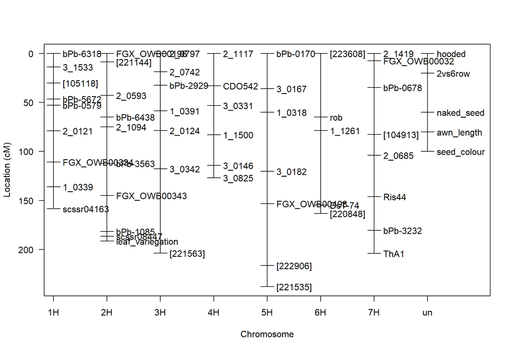

Figure 5: Genetic linkage mapping of the leaf variegation trait leaf_var (moved to the position with the highest LOD score of 3.83)

```r
# Map the leaf variegation marker to the most likely locus responsible
# for the trait
dta_linkage_map_qualt_phenotypes <- map_qualt_trait(
  dta_linkage_map_qualt_phenotypes,
  "leaf_variegation",
  load_scores
)

# Plot the updated linkage map
qtl::plotMap(dta_linkage_map_qualt_phenotypes,
  main = "",
  show.marker.names = TRUE
)
```

**Conclusion:** The leaf variegation of the Oregon Wolfe barley collection is significantly effected by the chromosome 2H at position 192.8. According to Giménez et al. (2021), the leaf variegation is controlled by the gene *Wst*. Figure 6 shows their phenotypic trait mapping results, which are in accordance with our findings.

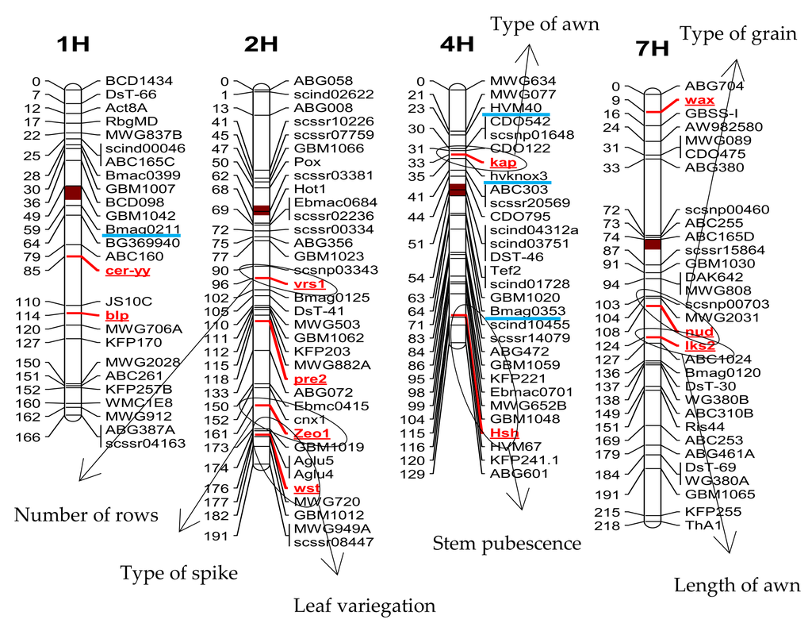

Figure 6: Phenotypic traits mapping of the Oregon Wolfe Barley population. From “An F2 barley population as a tool for teaching mendelian genetics”, by Giménez, E., Benavente, E., Pascual, L., García-Sampedro, A., López-Fernández, M., Vázquez, J. F., & Giraldo, P., 2021, Plants, 10(4), p. 694 (https://doi.org/10.3390/plants10040694#sec2-plants-10-00694).

# References

Giménez, E., Benavente, E., Pascual, L., García-Sampedro, A., López-Fernández, M., Vázquez, J. F., & Giraldo, P. (2021). An F2 barley population as a tool for teaching mendelian genetics. *Plants*, *10*(4), 694. https://doi.org/10.3390/plants10040694